# ps_4

James Hutt

02/03/2020

## Q1: Mad Libs

ML 1) The standard deviation of median income, plus one, is 14457.

ML 2) Treasure County, Montana is located in the state of Montana.

ML 3) The upper bound for median income in Etowah County, Alabama (geoid = “01055”) is 45799.

## Q2: Mapping

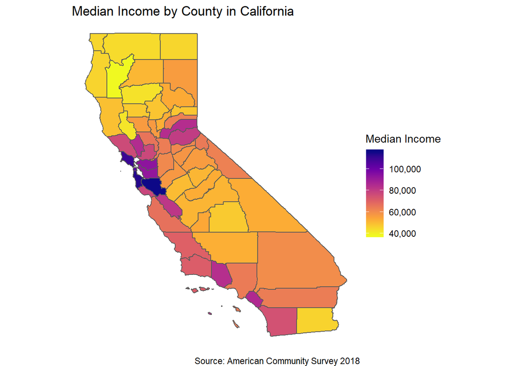

## Q3: Publishing to Rpubs

URL: https://rpubs.com/huttjames/580742

## Q4: Understanding Tufte Reading

I suspect Tufte would not have been a fan of this Powerpoint – if there are any that he would be a fan of! This one falls foul on a few of the problems he identifies. 1) Numeric content of visuals. The bar chart on slide 2 actually presents only 13 numbers, though takes up the whole of the slide. Even with such low information density the state names are hard to read, and the eye is only really caught by California and United States which are highlighted. This is also just a snapshot for one year in question. The data could better be presented as a data table, printed, with all 50 states and the changes over time, rather than for one year. Slide 3 actually has 0 numbers! 2) Logos The LAO logo is on every slide. They should not be the most important part of the presentation. The information is. Or the audience. Not the presenter. 3) Bullet structure Bullets regularly remove subtlety and links in information. Particularly egregious is “Issues” on p16 which lumps all the possible objections under one heading, as if they were of subordinate importance. Similarly, the criteria on p5 are all presented equally, removing any suggestion that the factors may be of differing importance, or competing with each other.

## Q5: Writing a Function

5A: d

5C:

Selected Throw for Each of the 4 Players

Selected Throw is earliest alphabetically of 3 separate rolls

| Results |
| --- |
| b, a, e, f |
| w, a, v, h |
| d, j, e, d |
| n, e, e, p |
| a, b, c, m |

The selected value (representative of Alyssa’s roll) was a vowel 32 times.

5D: Given the percentage of Alyssa’s rolls which were vowels was 32% I would expect all 4 to roll a vowel 1.05% of the time, since the rolls are independent.

We can simulate this with the following tibble, of which only the first 50 rows are shown:

Selected Throw for Each of the 4 Players

Selected Throw is earliest alphabetically of 3 separate rolls

| Results | All Vowels? |
| --- | --- |
| b, n, b, p | FALSE |
| v, b, o, n | FALSE |
| c, q, b, l | FALSE |
| e, m, a, h | FALSE |
| f, d, c, e | FALSE |
| e, b, m, c | FALSE |
| q, n, r, i | FALSE |
| k, c, b, g | FALSE |
| e, k, e, g | FALSE |
| c, b, b, j | FALSE |
| n, i, e, a | FALSE |
| f, i, h, e | FALSE |
| q, a, a, d | FALSE |
| a, s, s, h | FALSE |
| b, m, e, h | FALSE |
| r, s, b, f | FALSE |
| a, b, f, i | FALSE |
| m, m, b, f | FALSE |
| b, h, g, a | FALSE |
| j, f, d, h | FALSE |
| d, c, h, d | FALSE |
| b, e, a, a | FALSE |
| d, d, g, d | FALSE |
| h, i, a, d | FALSE |
| b, e, a, p | FALSE |
| c, j, b, n | FALSE |
| f, c, e, t | FALSE |
| b, m, h, i | FALSE |
| c, c, h, g | FALSE |
| a, g, f, q | FALSE |
| q, g, e, o | FALSE |
| g, c, c, c | FALSE |
| r, d, b, j | FALSE |
| j, b, p, m | FALSE |
| i, b, f, g | FALSE |
| h, l, c, c | FALSE |
| a, g, b, o | FALSE |
| l, a, g, e | FALSE |
| f, b, m, g | FALSE |
| a, k, h, h | FALSE |
| w, m, n, h | FALSE |
| g, j, v, d | FALSE |
| f, m, a, b | FALSE |
| n, c, b, l | FALSE |
| b, c, r, m | FALSE |
| m, o, d, b | FALSE |
| h, a, a, b | FALSE |
| m, s, f, c | FALSE |
| f, j, j, f | FALSE |
| g, a, e, f | FALSE |

Of the 10,000 games 49 saw all 4 players roll vowels. This is 0.49%.

5E: The below chart shows the distribution of “first” letters from 1000 plays of the game by a single player.

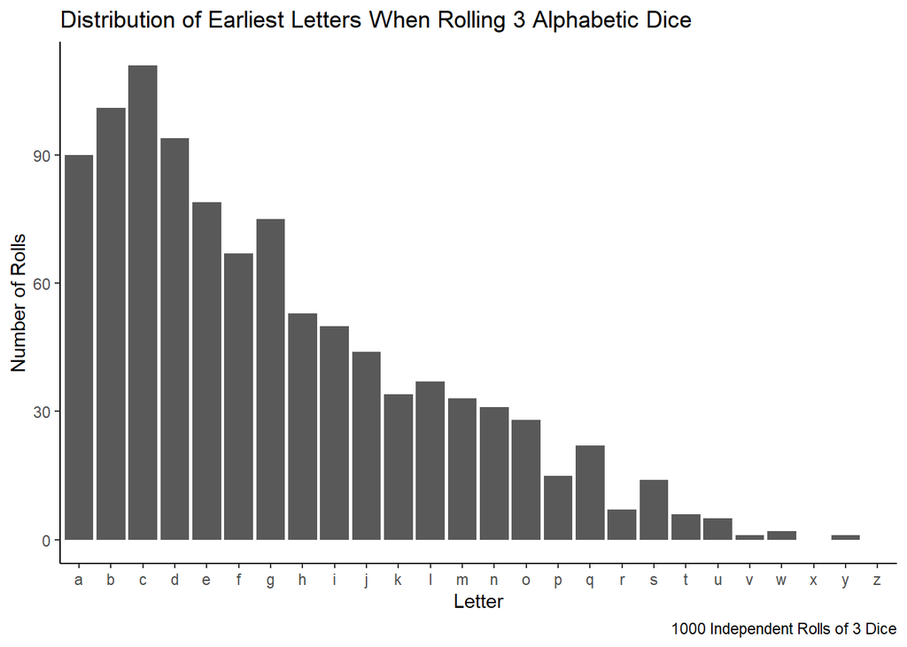

5F: The below chart shows the distribution of “first” letters from 1000 plays of the game by a single player when they have 3 or 5 rolls respectively.

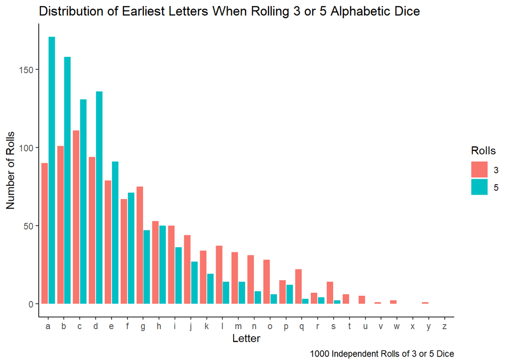

As we can see, the distribution when rolling 5 dice is shifted to the left. This makes sense as if we roll more dice, and can choose any of them, then the worst result we can do is the same as at the end of the third roll, however we might improve what we picked. Thus, in expectation, each result will be earlier in the alphabet and the distribution as a whole will be shifted downwards.

PSet Pals: Taylor Greenberg Goldy